# Worldwide HIV cases (Jan’s project)

Bernhard

## First step: tidying up data.

Column `Location` gets renamed to `Country`, column `Period` gets renamed to `Year` and column `FactValueNumeric` will be renamed to `Cases`.

Note: I held the plots in a *mourning color* by purpose.

## Second step: cases by year

The worldwide HIV cases by year from 2000 to 2021 are shown in this plot. The year with the most cases is highlighted.

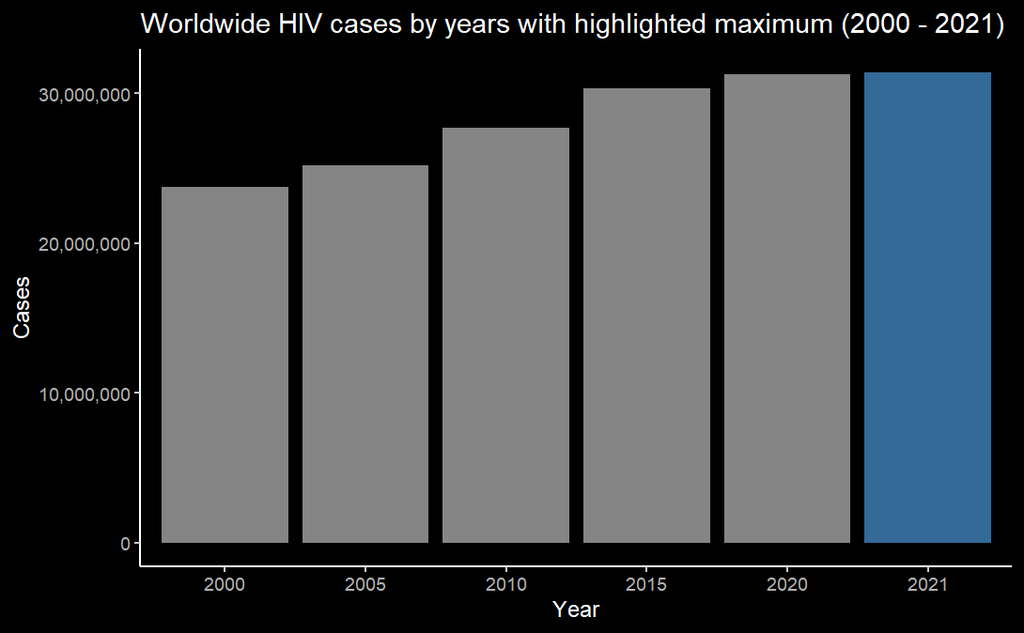

As we can see 2021 was the year with the most HIV cases during the time period of 2000 and 2021.

## Third step: cases by country

This chart shows the development of HIV cases from 2000 to 2021 of the 5 countries with the most cases over that time period.

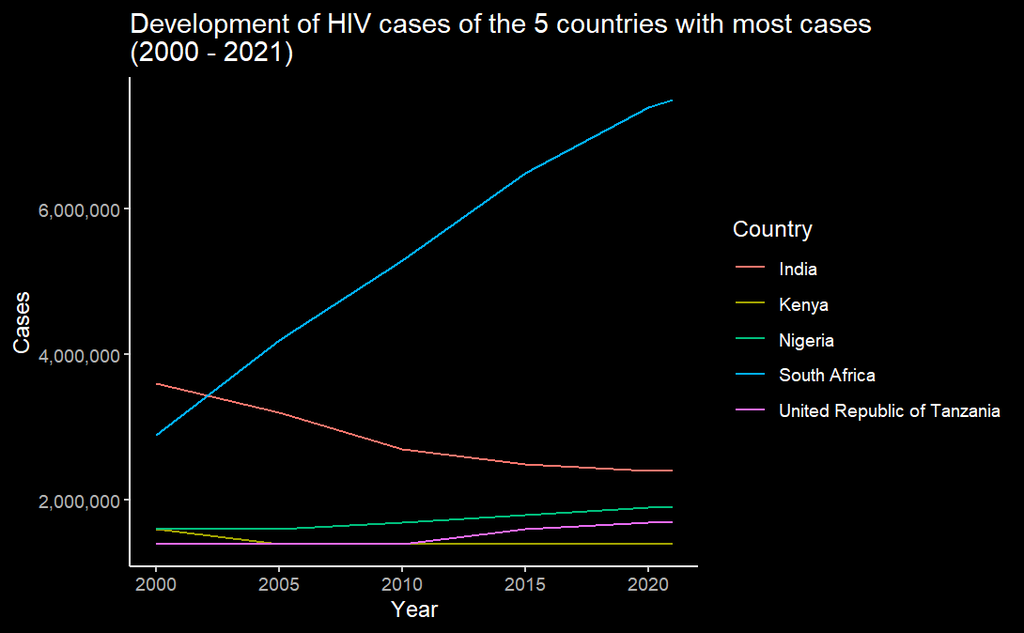

As the chart shows, in all the countries but South Africa the HIV cases are either decreasing or at a relative stable level. South Africa shows a steep increase in case numbers and hence must be the main cause for the rising cases worldwide that the first chart shows.

## Fourth step: 5 year interval *summary*

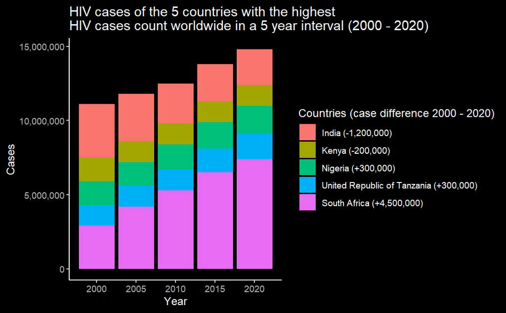

This chart gives an overview over the HIV cases of the five most affected countries worldwide. The cases are shown in a 5 year interval. This chart can be seen as a summary of the foregoing charts.

In addition, the stacked countriese are sorted by increase/decrease of the case numbers from 2000 to 2020 with the country nearest to the x-axis having the largest increase (South Africa) while the topmost (India) the lowest. As the foregoing chart shows India had a decrease in HIV infections during the analysed time period.

Hopefully, it’s beautiful enough.